# Open Science Workflow Cheatsheet – Open Science Workflow Training for ISC

## Key terms

- **Repository**: A place to store code, files, and each file’s revision history.
- **Local Computer**: Your physical computer.
- **Remote**: Computer that is located elsewhere and accessed over a network (e.g. the internet).
- **Render**: Generate documents, presentations and more. Produce HTML, PDF, MS Word, reveal.js, MS Powerpoint, Beamer, websites, blogs, books…

## Git and GitHub

### Starting a repository

```
flowchart TD
    A(Do you have a directory already started on your local computer?  ) --Yes--> B(git init)
    A --No  --> C(git clone repository_url)
```

**`git init`**: Initialize a Git repository on a local computer.  
**`git clone repository_url`**: Copying an entire repository onto a local computer.

### Making changes to repository

**`git status`**: Check what files have changed.  
**`git restore filename`**: Undo changes to a file. **`git reset --soft`**: Moves changes from a commit back to the staging area.  
**`git revert <commit ID>`**: Creates a new commit that reverts the repo to a previous commit. **`git commit --amend`**: Make changes to the last commit/commit message.

```
flowchart LR
    A(Local computer) --> B(Stage changes: git add)
    B --> C(Commit changes: git commit -m)
    C --> D(Push changes to remote repository: git push)
    D --> E(Remote repository)
```

```
flowchart LR
    A(Remote repository) --> B(Pull changes from remote: git pull)
    B --> C(Local computer)
```

#### From your local computer

**`git add`**: Stage changes for a local commit.  
**`git commit -m "short, descriptive message"`**: Commit changes to be tracked.  
**`git push`**: Push changes from local computer up to the remote repository.

#### From remote repository

**`git pull`**: Pull changes from the remote repository to your local computer.  
**`git pull origin main`**: Pull changes from the remote repository **main** branch to the branch you are on.

### Branches

**`git checkout -b branch_name`**: Create a new branch.  
**`git checkout branch_name`**: Switch to a different branch.  
**`git switch`**: Switch to a different branch.

### Example workflow

When working within a `git` enabled project it is generally good practice to not work directly on the `main` branch but to work in an alternative branch that can be pulled into the `main` branch.

## VSCode

An IDE (integrated development environment) that works well with many languages.

### Side Bar Options

#### File Explorer

To browse the files in a project

[figure not shown]

#### Git GUI (Source Control)

To interact with your GitHub repository

[figure not shown]

#### Extensions

VS Code’s version of the app store

[figure not shown]

#### R

Similar to the options available in RStudio for viewing variables in your environment, function documentation, and installing packages.

[figure not shown]

### Command Palette

Use the shortcut `ctl + shift + P` to access.

[figure not shown]

### Terminal

Can have multiple terminals of different languages running at a time.

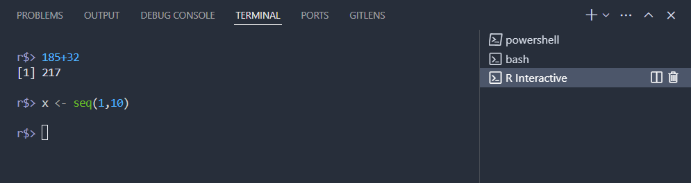

## renv

#### Initialize renv for a project

**`renv::init()`**: Set up a project library for a new or existing project.

#### Install new packages

**`renv::install()`**: Install packages from CRAN, GitHub, etc..

#### Lockfile

**`renv::snapshot()`**: Update the lockfile (`renv.lock`) with packages being used.  
**`renv::restore()`**: Reinstall the packages specified in the lockfile.

### Example workflow

If working within a project where `renv` is already used and enabled, an initial call to `renv::restore()` will install all packages named in the `renv.lock` file.

If `renv` has not been enabled, an initial call to `renv::init()` will enable `renv`. `renv` will then crawl through all directories in your project searching for `.r` or `.R` files and identify packages that are explicitly referenced in *active* code using `library()`, `require()`, or `::`. These packages (as well as their versions and sources) will then be captured in the `renv.lock` file.

As you add code to the repository it is good practice to periodically run `renv::status()` to see if there are any discrepancies between the packages that are used and those that are recorded in the `renv.lock` file. If there are discrepancies, you can use `renv::install()` to install the missing packages. Then `renv::snapshot()` can be used to update the `renv.lock` file to add/remove any packages.

Packages can be updated to the newest version using the `renv::update()` though do so at your own risk as updates could result in code that no longer works.

Calls to `renv::install()` or `renv::update()` without specifying an argument will install or update all needed packages. However, if you only want to install or update a particular package you can do so by specifying it as an argument (e.g., `renv::install("data.table")`). By default packages will be installed from [CRAN](https://cran.r-project.org/) however you can specify installation from a specific Github repository by specifying the repository owner and name (e.g., `renv::install("PIFSCstockassessments/ss3diags")`).

## Shiny

**`ui.R`**: the interactive user interface code (to show stuff)  
**`server.R`**: the code for computations and plotting (to do stuff)  
**`shiny::shinyApp()`**: launches the app

#### Useful resources

- [Shiny widgets](https://dreamrs.github.io/shinyWidgets/): a gallery of user interface widgets to include in an app
- [AI assistant for Shiny](https://gallery.shinyapps.io/assistant/)
- [Shiny live!](https://shinylive.io/r/examples/): An interactive development environment for Shiny apps

## Quarto

#### Document format

In the header yaml, specify what format(s) you want to create.

```yaml
---
title: "Open Science Workflow Cheatsheet"
format: html
---
```

`format` options include:

- html
- pdf
- revealjs
- docx
- and more!

#### Including code

Include code blocks in a document

````markdown
```{r}
#| echo: true

x <- 2+2
```
````

Calculated values can be reported in text later: $x =$ 4.

And control the output rendered in the document with execution options.

| Option | Effects |
| --- | --- |
| `echo` | show/hide code in output |
| `eval` | do/don’t run code |
| `include` | include/exclude code or results |
| `output` | include/exclude results |
| `warning` | show/hide warnings in output |
| `error` | show/hide error in output and continue with render |

#### Include diagrams

You can elso embed [Mermaid](https://mermaid.js.org/) diagrams directly into a Quarto document using code chunks. The following code…

```
flowchart LR
    A(Remote repository) --> B(Pull changes from remote: git pull)
    B --> C(Local computer)
```

… produces the following diagram.

```
flowchart LR
    A(Remote repository) --> B(Pull changes from remote: git pull)
    B --> C(Local computer)
```

#### To render document

To render a quarto file to the proper format, in your terminal (not R), run:

```bash
quarto render path/to/file/name.qmd
```

#### Useful resources

- `revealjs` slidecraft: check out these [examples by Emil Hvitfeldt](https://emilhvitfeldt.com/project/slidecraft-101/)
- [Quarto guide](https://quarto.org/docs/guide/)
- [Get started with Quarto](https://rstudio-conf-2022.github.io/get-started-quarto/)
- [Mermaid live!](https://mermaid.live/): An interactive development environment for Mermaid diagrams
- [Creating a website](https://quarto.org/docs/websites/)
- [Publishing Quarto Sites](https://quarto.org/docs/publishing/github-pages.html#:~:text=There%20are%20three%20ways%20to,publish%20from%20the%20docs%20directory.)

Back to top